# Efeito fixo versus efeito aleatório

- Show All Code
- Hide All Code
- View Source

Os dois conceitos centrais, sem jargão

Author

Marcelo Silva

Published

October 8, 2026

## 1 Dois tipos de efeito

O modelo misto separa a influência sobre a resposta em duas partes. Entender essa separação é o primeiro passo.

### 1.1 Efeito fixo

É o que queremos estimar e interpretar: o efeito do próprio fator em estudo na população. Exemplos:

- Efeito de um fármaco (versus placebo) sobre a pressão arterial.
- Diferença entre duas dietas no ganho de peso.
- Efeito do tempo (dia 0, 7, 14) na carga viral.

### 1.2 Efeito aleatório

É a variação que vem do agrupamento e que não queremos estimar ponto a ponto, só descrever sua dispersão. Exemplos:

- Cada paciente tem sua linha de base própria, ou seja, o seu comportamento ao longo do experimento.
- Cada hospital tem condições ligeiramente diferentes.
- Cada lote de reagentes introduz ruído dentro do experimento.

**ImportantPERGUNTA**

Quanto da variação total vem das diferenças entre grupos? E não “qual o valor exato de cada grupo?”

Exemplo:

- O quanto da satisfação do paciente em relação ao pós-cirúrgico é influencaido pelo hospital que ele foi atendido?
- O quanto da variação observada no crescimento do esferóide é atribuido à réplica biológica?

## 2 A equação resumida

```
resposta = efeitos fixos + efeitos aleatórios + erro
```

## 3 Exemplo

Simulamos dados onde a interceptação varia por sujeito (efeito aleatório) e o tempo tem efeito comum (efeito fixo).

### 3.1 Gráfico de macarrão (*spaghetti plot*)

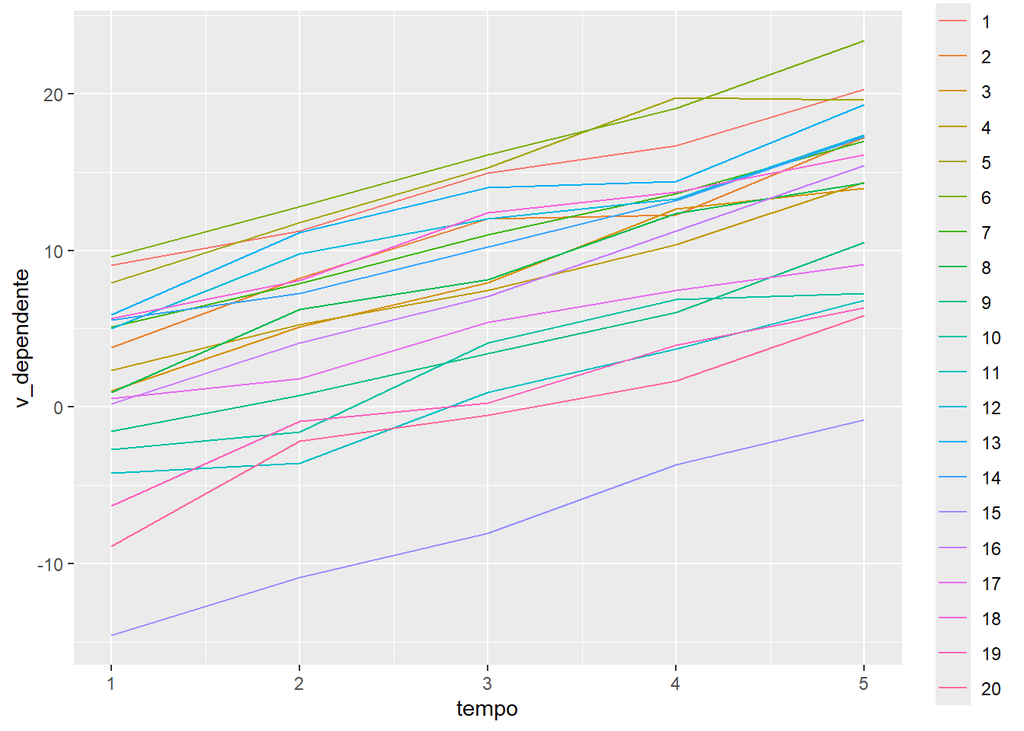

```r
library(tidyverse)
d %>%
  ggplot(aes(x = tempo, y = v_dependente, color = sujeito)) +
  geom_line()
```

### 3.2 Modelo

```r
# (1 | sujeito): interceptação aleatória; tempo é efeito fixo
modelo <- lmer(v_dependente ~ tempo + (1  |sujeito), data = d)
summary(modelo)
```

```
Linear mixed model fit by REML. t-tests use Satterthwaite's method [
lmerModLmerTest]
Formula: v_dependente ~ tempo + (1 | sujeito)
   Data: d

REML criterion at convergence: 384.2

Scaled residuals:
     Min       1Q   Median       3Q      Max
-2.06994 -0.52632 -0.05003  0.57384  1.92266

Random effects:
 Groups   Name        Variance Std.Dev.
 sujeito  (Intercept) 36.8734  6.0723
 Residual              0.9623  0.9809
Number of obs: 100, groups:  sujeito, 20

Fixed effects:
            Estimate Std. Error       df t value Pr(>|t|)
(Intercept) -1.63288    1.37717 19.89561  -1.186     0.25
tempo        3.04619    0.06936 79.00000  43.916   <2e-16 ***
---
Signif. codes:  0 '***' 0.001 '**' 0.01 '*' 0.05 '.' 0.1 ' ' 1

Correlation of Fixed Effects:
      (Intr)
tempo -0.151
```

```r
cat("\nEfeito fixo de tempo (estimado):",
    round(fixef(modelo)["tempo"], 2), "\n")
```

```
Efeito fixo de tempo (estimado): 3.05
```

```r
cat("Variância entre sujeitos (aleatória):",
    round(VarCorr(modelo)$sujeito[1], 2), "\n")
```

```
Variância entre sujeitos (aleatória): 36.87
```

Observe o df da tabela fixed effects. Veja que os graus de liberade (df) do Intercept fica próximo do número de sujeitos (nesse caso de exemplo são 20) e que os graus de liberdade (df) do tempo fica próximo do número de linhas da tabela (observações) menos o número de parâmetros (no caso, o número de sujeitos que são 20).

O valor fixo do Estimate perto de 3 significa que *se eu aumento em 1 unidade o tempo, eu aumento em 3 unidades a minha variável dependente.* O valor do p confirma o efeito do tempo.

### 3.3 O que você pergunta e o modelo responde

1. As pessoas mudam em ritmos diferentes ao longo do tempo?

*R: Não sei. O modelo está forçando todos a ter a mesma taxa de mudança (3,046/unidade de tempo)*

2. As pessoas começam em lugares diferentes?

*R: Sim, muito diferentes, por isso a grande variância do intercepto.*

3. O modelo está perdoando variação de inclinações?

*R: Sim porque se houver variação real nas inclinações, ela está sendo absorvida pelo resíduo (pequeno no caso: 0,96) ou não está sendo modelada.*

Agora, se você pergunta *“As pessoas mudam de forma diferente em relação ao tempo?”* seria necessário falar com o modelo para considerar uma inclinação diferente para cada sujeito. Veja abaixo

```r
## MODELANDO O SUJETIO (INTERCEPTOS ALEATÓRIOS)
modelo <- lmer(v_dependente ~ tempo + (1  |sujeito), data = d)
summary(modelo)
```

```
Linear mixed model fit by REML. t-tests use Satterthwaite's method [
lmerModLmerTest]
Formula: v_dependente ~ tempo + (1 | sujeito)
   Data: d

REML criterion at convergence: 384.2

Scaled residuals:
     Min       1Q   Median       3Q      Max
-2.06994 -0.52632 -0.05003  0.57384  1.92266

Random effects:
 Groups   Name        Variance Std.Dev.
 sujeito  (Intercept) 36.8734  6.0723
 Residual              0.9623  0.9809
Number of obs: 100, groups:  sujeito, 20

Fixed effects:
            Estimate Std. Error       df t value Pr(>|t|)
(Intercept) -1.63288    1.37717 19.89561  -1.186     0.25
tempo        3.04619    0.06936 79.00000  43.916   <2e-16 ***
---
Signif. codes:  0 '***' 0.001 '**' 0.01 '*' 0.05 '.' 0.1 ' ' 1

Correlation of Fixed Effects:
      (Intr)
tempo -0.151
```

```r
## MODELANDO O SUSJEITO E O SLOPE

modelo_inclinacao <- lmer(v_dependente ~ tempo + (1 + tempo | sujeito), data = d)
summary(modelo_inclinacao)
```

```
Linear mixed model fit by REML. t-tests use Satterthwaite's method [
lmerModLmerTest]
Formula: v_dependente ~ tempo + (1 + tempo | sujeito)
   Data: d

REML criterion at convergence: 383.7

Scaled residuals:
    Min      1Q  Median      3Q     Max
-1.9220 -0.5316 -0.0700  0.5617  1.9973

Random effects:
 Groups   Name        Variance Std.Dev. Corr
 sujeito  (Intercept) 38.68229 6.2195
          tempo        0.01234 0.1111   -0.46
 Residual              0.93259 0.9657
Number of obs: 100, groups:  sujeito, 20

Fixed effects:
            Estimate Std. Error       df t value Pr(>|t|)
(Intercept) -1.63288    1.40904 19.00010  -1.159    0.261
tempo        3.04619    0.07266 19.00011  41.923   <2e-16 ***
---
Signif. codes:  0 '***' 0.001 '**' 0.01 '*' 0.05 '.' 0.1 ' ' 1

Correlation of Fixed Effects:
      (Intr)
tempo -0.292
```

```r
anova(modelo, modelo_inclinacao)
```

|  | npar | AIC | BIC | logLik | -2*log(L) | Chisq | Df | Pr(>Chisq) |
| --- | --- | --- | --- | --- | --- | --- | --- | --- |
| modelo | 4 | 391.120 | 401.5407 | -191.5600 | 383.120 | NA | NA | NA |
| modelo_inclinacao | 6 | 394.669 | 410.3001 | -191.3345 | 382.669 | 0.4509823 | 2 | 0.7981241 |

**As diferenças em relação ao modelo anterior:**

Em Random effects, observe que agora tem tempo com Variance de 0.01. Ou seja, o quanto a inclinação da reta varia entre sujeitos. O desvio padrão é 0.11 é em torno do slope (inclinação) médio de 3.04. Em Random Effects, o Residual continua pequne (0.93).

### 3.4 E se um ANOVA fosse feito, sem considerar o pareamento

```r
modelo_errado <- lm(v_dependente ~ tempo, data = d)
summary(modelo_errado)
```

```
Call:
lm(formula = v_dependente ~ tempo, data = d)

Residuals:
     Min       1Q   Median       3Q      Max
-16.0122  -4.1060   0.8627   3.9310   9.8042

Coefficients:
            Estimate Std. Error t value Pr(>|t|)
(Intercept)  -1.6329     1.4209  -1.149    0.253
tempo         3.0462     0.4284   7.110  1.9e-10 ***
---
Signif. codes:  0 '***' 0.001 '**' 0.01 '*' 0.05 '.' 0.1 ' ' 1

Residual standard error: 6.059 on 98 degrees of freedom
Multiple R-squared:  0.3403,    Adjusted R-squared:  0.3336
F-statistic: 50.56 on 1 and 98 DF,  p-value: 1.898e-10
```

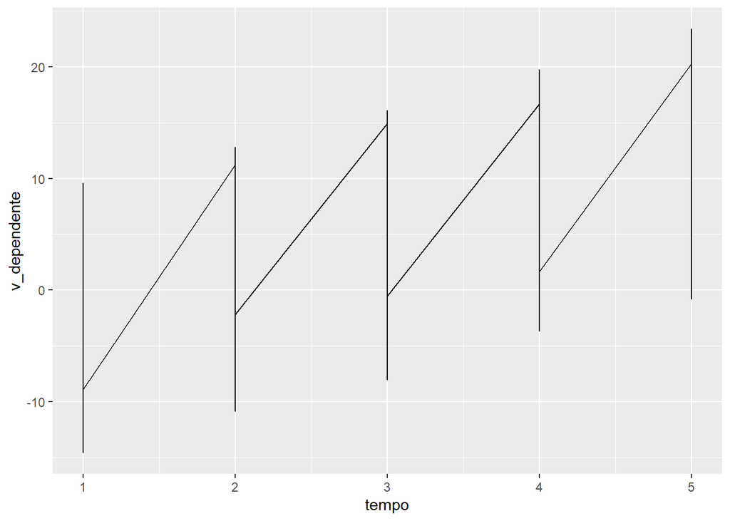

```r
d %>%
  ggplot(aes(x = tempo, y = v_dependente)) +
  geom_line()
```

Qual a diferença desse modelo errado com o modelo certo?